# DS Minor: Lab 01 – Networks Intro

### “Все связано”

- взаимосвязи между людьми (профессиональные, дружеские, семейные,..)
- связи между организациями, союзами, странами…
- связи между предметами (компьютеры, книги, фильмы…)
- связи между понятиями
- …

Два основных понятия – вершины (узлы, vertices, nodes) и связи (дуги, ребра, links, edges).

- что может являться вершинами и связями в списке выше?
- приведите свои примеры

Немного примеров

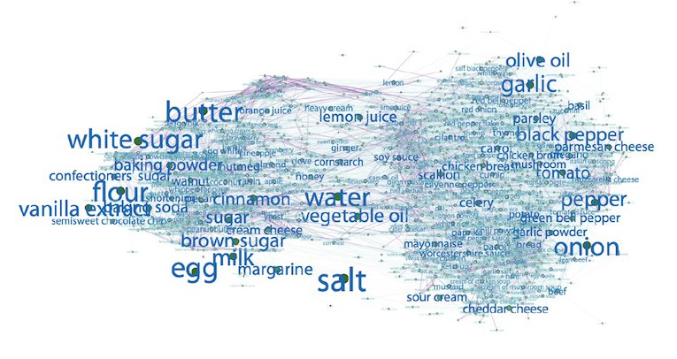

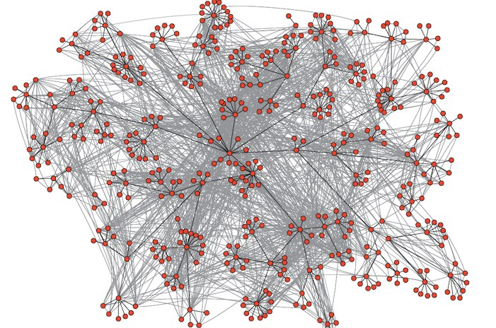

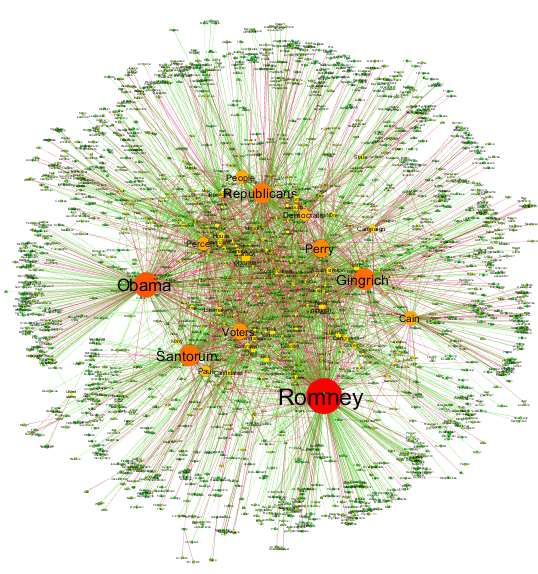

### Зачем изучать сети?

Рассмотрим те же примеры. Зачем нам нужно изучать связи? - взаимосвязи между людьми (профессиональные, дружеские, семейные,..) - связи между организациями, союзами, странами… - связи между предметами (компьютеры, книги, фильмы…)

Подробнее и еще примеры `~/shared/minor2_2016/2-datatech/books/barabasi-book_chapter_1.pdf`

- как вы думаете, анализ сетей (network science) – это новая область или нет? Почему?

### Формализация сетей – графы

#### Термины и понятия

- граф (graph)
- вершина, узел (node)
- ребро (edge)
- ориентированные (направленные) / неориентированные графы (directed / undirected graph)
- список ребер (edgelist)
- матрица смежности (adjacency matrix)

#### Инструмент

Мы будем работать с пакетом `igraph` для создания и работы с направленными и ненаправленными графами (http://igraph.org/r/)

```r
library(igraph)
```

#### Небольшие примеры для обсуждения понятий

**Граф** – способ формально описать взаимосвязи между набором элементов (**вершин, nodes**). **Ребро (edge)** – связь между элементами, представляется как пара вершин (начало-конец)

**Ориентированный граф** – несимметричная связь, направление важно. **Неориентированный граф** – симметричная связь (*A* и *B* связаны).

- какие графы являются ориентированными? Неориентированными?
- сколько вершин в графах? Ребер?

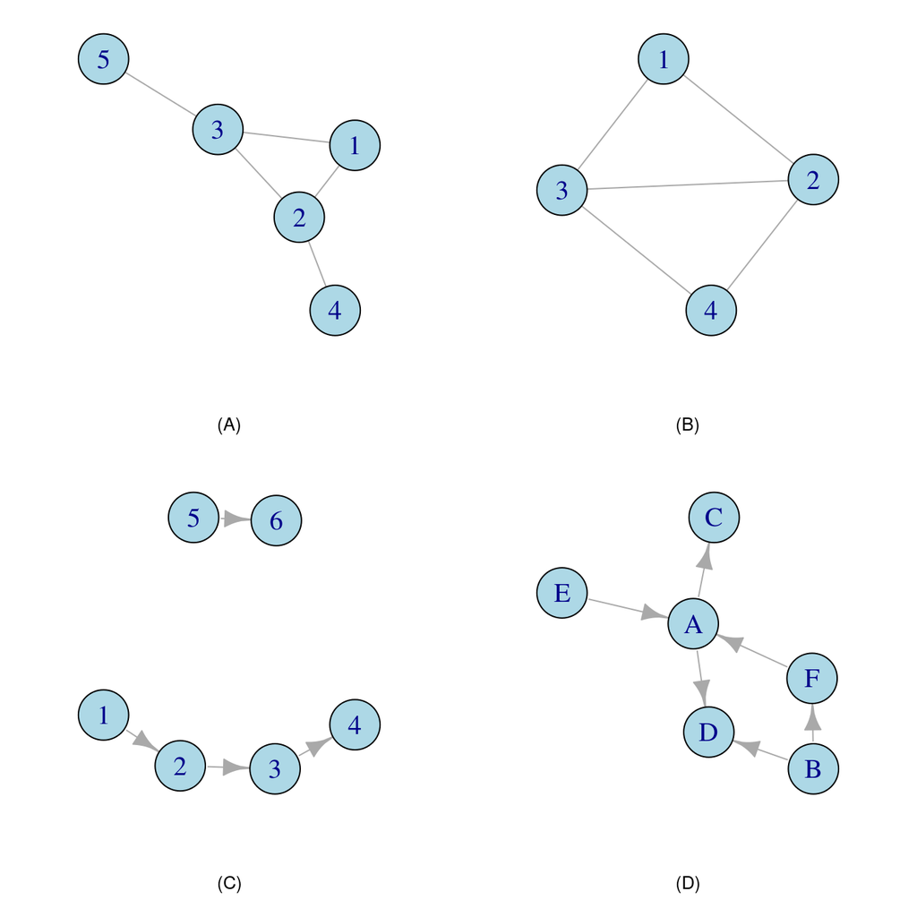